# Problem Statement

It may seem easy for a human to tell a profound statement from a mundane/shallow one, but what really makes a statement profound? For this project, I seek to answer 3 questions:

1. Is there a **pattern** to profound sentence?
2. Can we develop a **subreddit classifier** to classify statements from r/oneliners (for mundane/shallow statements) vs r/quotes (for profound statements)?
3. Can the classifier **generalize** to identify any profound statement?

By answering these 3 questions, I hope that it will enhance our understanding of this deeper end of the human ingenuity and offer some insights to what makes a statement profound/important.

This is a project of personal interest. But for a future application, it could even help us in filtering a long text to extract the important and profound information.

*Note*: We will mainly look at classifier performance by looking at the accuracy score, however, analysis will be performed on both classes to analyse the misclassification for each class.

# Datasets

A total of **52197** posts were collected from r/oneliners and r/quotes:

**Class 0: r/oneliners**

- 22,479 posts
- r/oneliner is a collection of succinct, funny or witty remark. The statement should fit into one sentence.
- We take these quotes to be the anti-thesis of a profound quote, which means they are usually mundane, shallow and trivial (although they can be really funny)

**Class1: r/quotes**

- 29,718 posts
- r/quotes is subreddit of a collection of current quotes, historic quotes, movie quotes, song lyric quotes, game quotes, book quotes, tv quotes or any gem of wisdom.
- We take these quotes to be profound quotes

*Note*

1. To ensure consistency, care was taken to only extract posts which are only one line statements. Otherwise, posts from r/quotes may contain quotes that consists of multiple sentences.
2. To ensure generalizability, only the statement itself was used for our analysis and modelling. Other features such as post self texts, comments, upvotes, etc were not taken into consideration

# Set-up

## Import Libraries

```python
# import necessary libraries
import pandas as pd
import numpy as np
import re

from sklearn.model_selection import train_test_split, GridSearchCV, ShuffleSplit
from sklearn.pipeline import Pipeline
from sklearn.naive_bayes import MultinomialNB, GaussianNB
from sklearn.linear_model import LogisticRegression
from sklearn.ensemble import RandomForestClassifier, GradientBoostingClassifier
from sklearn.svm import SVC
from sklearn.metrics import confusion_matrix, plot_confusion_matrix
from sklearn.feature_extraction.text import CountVectorizer, TfidfVectorizer
from sklearn.compose import ColumnTransformer
from sklearn.preprocessing import MaxAbsScaler, StandardScaler, FunctionTransformer
from sklearn.decomposition import TruncatedSVD

from nltk import pos_tag
from nltk.tokenize import sent_tokenize, word_tokenize, RegexpTokenizer
from nltk.stem import WordNetLemmatizer
from nltk.stem.porter import PorterStemmer
from nltk.corpus import stopwords
from nltk.sentiment.vader import SentimentIntensityAnalyzer
import nltk
import textstat

from itertools import combinations

import matplotlib.pyplot as plt
from matplotlib import gridspec
import matplotlib.pylab as pylab
import seaborn as sns

import pickle
import cloudpickle
import sys

import warnings
warnings.simplefilter(action='ignore', category=FutureWarning)
```

## Plotting settings

```python
# Settings
pd.set_option("display.max_columns", 50)
sns.set_theme(style = 'white')

params = {'legend.fontsize': 'x-large',
                            'axes.labelsize': 'large',
                            'axes.titlesize':'xx-large',
                            'xtick.labelsize':'medium',
                            'ytick.labelsize':'medium'}
pylab.rcParams.update(params)
```

## Useful functions

```python
# A combined boxplot and histogram plotter
def box_and_hist(df, x, y, categories, xlabel_box, ylabel_box, title):
                            fig = plt.figure(figsize = (20,10))

                            gs = gridspec.GridSpec(2, 2, figure=fig, width_ratios=[1, 3])

                            ax0 = fig.add_subplot(gs[:, 0]) # gs[row, col]
                            ax1 = fig.add_subplot(gs[:1, 1])
                            ax2 = fig.add_subplot(gs[1:, 1], sharex=ax1)

                            colors = {0:'#B87595', 1:'lightseagreen'}
                            sns.boxplot(data = df, x = x, y = y, palette= colors ,ax = ax0)

                            bin_num = np.histogram_bin_edges(df[df[x] == 0][y], bins='auto')
                            sns.histplot(data = df[df[x] == 0], x = y,
                            bins = bin_num, color = '#B87595', ax = ax1) # r/oneliners
                            sns.histplot(data = df[df[x] == 1], x = y,
                            bins = bin_num, color = 'lightseagreen', ax = ax2) # r/quotes

                            ax0.set_xticklabels(categories)
                            ax0.set_xlabel(xlabel_box)
                            ax0.set_ylabel(ylabel_box)
                            ax1.set_xlabel(ylabel_box)
                            ax2.set_xlabel(None)
                            ax2.invert_yaxis()
                            plt.suptitle(title, fontsize = "xx-large");

# The function to pass into the analyzer argument of count vectorizer - to lemmatize before vectorize
def lemmatized_words(words):
                            lemmatizer = WordNetLemmatizer()
                            analyzer = CountVectorizer().build_analyzer()
                            return (lemmatizer.lemmatize(w) for w in analyzer(words))

# Function to merge two dictionaries
def merge_two_dicts(d1, d2):
                            dm = d1.copy()
                            dm.update(d2)
                            return dm


# Function to find best parameter from a set of feature sets, vectorizers and estimators
def find_best_params(feature_sets, response, vectorizers, estimators, scaler, include_svd, scoring, cv, verbose):
                            """
    Function to find best parameter from a set of feature sets, vectorizers and estimators through gridsearch

    feature_sets = feature sets dictionary in the format {index:dataframe}
    response = Series consisting of the feature labels
    vectorizers = Vectorizer dictionary containing vectorizer instance and parameters
    estimators = Estimator dictionary containing estimator instance and parameters
    scaler = Pass in a scaler instance
    include_svd = False or int. If False, will not perform dimensionality reduction with TruncatedSVD before estimator,
    if int, will perform TruncatedSVD with int value as num_components
    scoring = str of the scoring metric to use for gridsearch
    cv = number of cross validation folds
    verbose= The level of detail of information to print while performing fits

    """
                            grid_search_result = []

                            # loop through the feature sets dict
                            for i, feature_set in feature_sets.items():
                            print(f"------------------- Feature Set {i} --------------------")
                            X = feature_set
                            y = response


                            #--------------------------------------------------------------------------------
                            # loop through the 2 vectorizers
                            for vectorizer_name, vectorizer_info in vectorizers.items():

                            print(f'Start {vectorizer_name}')

                            # The preprocessor will vectorize 'title' column and then concat the other columns to it
                            preprocessor = ColumnTransformer(
                            [(vectorizer_name, vectorizer_info['vectorizer'], 'title')],
                            remainder = 'passthrough')

                            #----------------------------------------------------------------------------------
                            # loop through the estimators dict
                            for estimator_name, estimator_info in estimators.items():
                            grid_search_result_row = {} # stores best result of a estimator

                            if include_svd:
                            print(f'Start {estimator_name} with TruncatedSVD')
                            pipe = Pipeline(steps=[('preprocessor', preprocessor),
                            ('scaler', scaler),
                            ('TSVD', TruncatedSVD(n_components = include_svd)),
                            (estimator_name, estimator_info['estimator'])])
                            else:
                            print(f'Start {estimator_name} without TruncatedSVD')
                            pipe = Pipeline(steps=[('preprocessor', preprocessor),
                            ('scaler', scaler),
                            (estimator_name, estimator_info['estimator'])])

                            # merge the vectorizer and estimator params into a single param grid
                            param_grid = merge_two_dicts(vectorizer_info['params'], estimator_info['params'])

                            # create gridsearchcv object
                            grid_search = GridSearchCV(pipe, param_grid = param_grid,
                            scoring = scoring, verbose = verbose, cv=cv)
                            grid_search.fit(X, y) # fit gs object

                            # collect the important results
                            grid_search_result_row["feature_set"] = i
                            grid_search_result_row["vectorizer"] = vectorizer_name
                            grid_search_result_row["estimator"] = estimator_name
                            grid_search_result_row["grid search object"] = grid_search
                            grid_search_result_row["best estimator"] = grid_search.best_estimator_
                            grid_search_result_row["best score"] = grid_search.best_score_
                            grid_search_result_row["best params"] = grid_search.best_params_

                            print(f"{estimator_name} best accuracy score:", grid_search.best_score_)

                            grid_search_result.append(grid_search_result_row)

                            return grid_search_result
```

# Import data

Import data and perform necessary checks

```python
df = pd.read_csv("../data/subreddit_posts_cleaned.csv")
```

```python
print(df.shape)
df.tail()
```

```
(52205, 3)
```

|  | title | title_length | subreddit |
| --- | --- | --- | --- |
| 52200 | How about you? | 3.0 | oneliners |
| 52201 | Abstraction is drawing strength from a pool of... | 18.0 | oneliners |
| 52202 | Wanna hear a good joke? | 5.0 | oneliners |
| 52203 | We never really grow up, we only learn how to ... | 13.0 | oneliners |
| 52204 | If sex is a pain in the ass, then you’re doing... | 14.0 | oneliners |

```python
# check and drop null values from csv
df.isnull().sum()
```

```
title           7
title_length    0
subreddit       0
dtype: int64
```

```python
df = df.dropna()
df.reset_index(drop = True, inplace = True)
```

```python
df.isnull().sum()
```

```
title           0
title_length    0
subreddit       0
dtype: int64
```

# Preprocessing

## Convert subreddit to 0 and 1

```python
# 0 - r/oneliners
# 1 - r/quotes

df['subreddit'] = df['subreddit'].map({'oneliners':0, 'quotes':1})
```

```python
df['subreddit'].value_counts(normalize = True)
```

```
1    0.569351
0    0.430649
Name: subreddit, dtype: float64
```

Our dataset is rather balanced, with the majority class being 1 (r/quotes). This will be our baseline accuracy, our model has to achieve at least an accuracy of 0.569 to be considered better than a model just outputting the majority class.

## Vectorize sentence

### Stop words

Lets select the stop words for removal. We begin by first looking at the stop words offered by nltk

```python
print(stopwords.words('english'))
```

```
['i', 'me', 'my', 'myself', 'we', 'our', 'ours', 'ourselves', 'you', "you're", "you've", "you'll", "you'd", 'your', 'yours', 'yourself', 'yourselves', 'he', 'him', 'his', 'himself', 'she', "she's", 'her', 'hers', 'herself', 'it', "it's", 'its', 'itself', 'they', 'them', 'their', 'theirs', 'themselve…
```

From a brief look at our sentences, we suspect that pronounce such as I, you, etc could have an impact on classification between the 2 subreddits, as such, we will keep the pronounce. We will create a list of custom stop words.

```python
stopwords_custom = stopwords.words('english')[35:]
stopwords_custom[0]
```

```
'what'
```

## Feature engineering

Next we will generate more features which will give us additional information about the texts.

### Length of Words

We will find the average word length and the longest word length for each sentence.

```python
# Check if there are sentences with no words again
for i, sent in enumerate(df['title']):
                            split_str = re.findall(r"[\w+|\w+\'\w+]+", sent)
                            try:
                            max([len(w) for w in split_str])
                            except:
                            print(i, sent)
```

```
19675 ..................
```

```python
# We see a sentence with just periods, as such we will drop this
df = df.drop(index = 19675)
df.reset_index(drop=True, inplace = True)
```

```python
# Create average length and longest length features
def word_length(row):
                            # Using regex to find all words, including those with quotes such as what's
                            split_str = re.findall(r"[\w+|\w+\'\w+]+", row['title'])
                            num_words = row['title_length']
                            total_len = sum([len(w) for w in split_str])
                            row['average_length'] = total_len/num_words
                            row['longest_length'] = max([len(w) for w in split_str])
                            return row

df = df.apply(word_length, axis = 1)
```

```python
df.tail(3)
```

|  | title | title_length | subreddit | average_length | longest_length |
| --- | --- | --- | --- | --- | --- |
| 52194 | Wanna hear a good joke? | 5.0 | 0 | 3.600000 | 5 |
| 52195 | We never really grow up, we only learn how to ... | 13.0 | 0 | 3.538462 | 6 |
| 52196 | If sex is a pain in the ass, then you’re doing... | 14.0 | 0 | 2.928571 | 5 |

### Word readeability

#### Dale–Chall Readeability Score and Flesch reading ease

The Dale–Chall readability formula is a metric that provides a numeric score for the difficulty of a text. It keeps a list of 3000 easy words (comprehensible by 4th graders) and any word that falls outside is considered a difficult word. The full formula is given by:

**Score = 0.1579 *(PDW) + 0.0496* ASL**

where,

PDW = Percentage of difficult words not on the Dale–Chall word list

ASL = Average sentence length

The lower the score, the higher the sentence readeability.

#### Flesch reading ease

The Flesch–Kincaid readability tests are readability tests designed to indicate how difficult a passage in English is to understand. The formula is as follows:

**Flesch-Kincaid reading ease formula: 206.835 - 1.015 x (words/sentences) - 84.6 x (syllables/words)**

In this case, the lower the score, the lower the sentence readeability.

#### Creating features for readeability

We will use the Dale-Chall Readeability Score and Flesch Reading Ease as another feature of our text.

```python
def readeability_scores(row):
                            row["Dale–Chall_readeability_score"] = textstat.dale_chall_readability_score(row['title'])
                            row["Flesch-Kincaid_reading_ease"] = textstat.flesch_reading_ease(row['title'])
                            return row

df = df.apply(readeability_scores, axis = 1)
```

```python
print(df.shape)
df.head()
```

```
(52197, 7)
```

|  | title | title_length | subreddit | average_length | longest_length | Dale–Chall_readeability_score | Flesch-Kincaid_reading_ease |
| --- | --- | --- | --- | --- | --- | --- | --- |
| 0 | We all think we're right, and then we change o... | 17.0 | 1 | 4.058824 | 6 | 0.84 | 104.98 |
| 1 | Life feels good cause I just finger the bad bitch | 10.0 | 1 | 4.000000 | 6 | 7.29 | 103.63 |
| 2 | I am a God, So hurry up with my damn massage, ... | 24.0 | 1 | 3.416667 | 10 | 8.44 | 75.54 |
| 3 | Stories may well be lies, but they are good li... | 16.0 | 1 | 3.437500 | 7 | 6.59 | 99.57 |
| 4 | Don't pursue happiness, rather design a lifest... | 20.0 | 1 | 5.200000 | 9 | 9.57 | 52.19 |

### Sentiment score

We will use the VADER (Valence Aware Dictionary and sEntiment Reasoner) lexicon to analyze the sentiments of the sentences.

Sentiment analysis is a text analysis method that detects polarity (e.g. a positive or negative opinion) within the text.

The score consists of polarities scores of:

- Positive (0-1)
- Negative(0-1)
- Neutral(0-1)
- Compound(-1 to 1), which is an aggregated score of the first 3 scores. The closer a text is to 1, the more positive the text is.

```python
# A function to calculate compound score of all sentences in the dataframe
def compound_sentiment_score(row):
                            sent_analyzer = SentimentIntensityAnalyzer()
                            sent_result = sent_analyzer.polarity_scores(row['title'])

                            row['sentiment_negative_score'] = sent_result['neg']
                            row['sentiment_neutral_score'] = sent_result['neu']
                            row['sentiment_positive_score'] = sent_result['pos']
                            row['sentiment_compound_score'] = sent_result['compound']
                            return row

df = df.apply(compound_sentiment_score, axis = 1)
```

```python
df.head(2)
```

|  | title | title_length | subreddit | average_length | longest_length | Dale–Chall_readeability_score | Flesch-Kincaid_reading_ease | sentiment_negative_score | sentiment_neutral_score | sentiment_positive_score | sentiment_compound_score |
| --- | --- | --- | --- | --- | --- | --- | --- | --- | --- | --- | --- |
| 0 | We all think we're right, and then we change o... | 17.0 | 1 | 4.058824 | 6 | 0.84 | 104.98 | 0.000 | 1.00 | 0.000 | 0.0000 |
| 1 | Life feels good cause I just finger the bad bitch | 10.0 | 1 | 4.000000 | 6 | 7.29 | 103.63 | 0.451 | 0.37 | 0.179 | -0.6597 |

### Word tagging

Grammatically, each word in the english language can be classed into various categories such as noun, verbs, pronounce, etc. By 'tagging' the words into different classes, it may reveal different patterns between a profound quote and a funny sentence.

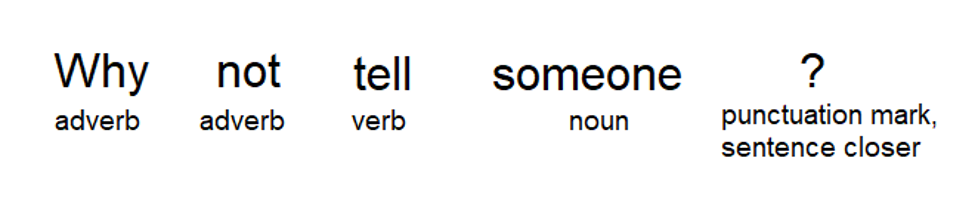

```python
def word_tagger(row):
                            tagged_list = pos_tag(word_tokenize(row['title']))
                            # get all tags
                            tags_tuples = [w[1] for w in tagged_list]
                            # get unique tags and count
                            tags, counts = np.unique(tags_tuples, return_counts=True)
                            for i, tag in enumerate(tags):
                            row[tag] = counts[i]
                            return row

df = df.apply(word_tagger, axis = 1)
```

```python
df.head(3)
```

|  | # | $ | '' | ( | ) | , | . | : | CC | CD | DT | Dale–Chall_readeability_score | EX | FW | Flesch-Kincaid_reading_ease | IN | JJ | JJR | JJS | MD | NN | NNP | NNPS | NNS | PDT | ... | RBS | RP | SYM | … |
| --- | --- | --- | --- | --- | --- | --- | --- | --- | --- | --- | --- | --- | --- | --- | --- | --- | --- | --- | --- | --- | --- | --- | --- | --- | --- | --- | --- | --- | --- | --- |
| 0 | NaN | NaN | NaN | NaN | NaN | 2.0 | 1.0 | NaN | 2.0 | NaN | 1.0 | 0.84 | NaN | NaN | 104.98 | NaN | 2.0 | NaN | NaN | NaN | 1.0 | NaN | NaN | NaN | NaN | ... | NaN | NaN | NaN | … |
| 1 | NaN | NaN | NaN | NaN | NaN | NaN | NaN | NaN | NaN | NaN | 1.0 | 7.29 | NaN | NaN | 103.63 | NaN | 2.0 | NaN | NaN | NaN | 2.0 | 1.0 | NaN | 1.0 | NaN | ... | NaN | NaN | NaN | … |
| 2 | NaN | NaN | NaN | NaN | NaN | 3.0 | NaN | NaN | NaN | NaN | 2.0 | 8.44 | NaN | NaN | 75.54 | 3.0 | NaN | NaN | NaN | NaN | 4.0 | 4.0 | NaN | 1.0 | NaN | ... | NaN | 2.0 | NaN | … |

3 rows × 55 columns

For ease of display, we will just separate the word tag columns and the other columns.

```python
non_word_tagged_col = ['title','title_length','subreddit','average_length','longest_length',
                            'Dale–Chall_readeability_score','Flesch-Kincaid_reading_ease',
                            'sentiment_negative_score', 'sentiment_neutral_score', 'sentiment_positive_score',
                            'sentiment_compound_score']
df_non_tags = df[non_word_tagged_col]
df_tags = df.drop(non_word_tagged_col, axis = 1)
```

```python
print(df_non_tags.shape)
df_non_tags.tail(3)
```

```
(52197, 11)
```

|  | title | title_length | subreddit | average_length | longest_length | Dale–Chall_readeability_score | Flesch-Kincaid_reading_ease | sentiment_negative_score | sentiment_neutral_score | sentiment_positive_score | sentiment_compound_score |
| --- | --- | --- | --- | --- | --- | --- | --- | --- | --- | --- | --- |
| 52194 | Wanna hear a good joke? | 5.0 | 0 | 3.600000 | 5 | 7.04 | 100.24 | 0.000 | 0.282 | 0.718 | 0.6249 |
| 52195 | We never really grow up, we only learn how to ... | 13.0 | 0 | 3.538462 | 6 | 0.64 | 75.20 | 0.000 | 1.000 | 0.000 | 0.0000 |
| 52196 | If sex is a pain in the ass, then you’re doing... | 14.0 | 0 | 2.928571 | 5 | 9.14 | 100.58 | 0.405 | 0.595 | 0.000 | -0.7783 |

```python
print(df_tags.shape)
df_tags.fillna(0, inplace = True) # change nan to 0
df_tags.head(3)
```

```
(52197, 44)
```

|  | # | $ | '' | ( | ) | , | . | : | CC | CD | DT | EX | FW | IN | JJ | JJR | JJS | MD | NN | NNP | NNPS | NNS | PDT | POS | PRP | PRP$ | RB | RBR | RBS | … |
| --- | --- | --- | --- | --- | --- | --- | --- | --- | --- | --- | --- | --- | --- | --- | --- | --- | --- | --- | --- | --- | --- | --- | --- | --- | --- | --- | --- | --- | --- | --- |
| 0 | 0.0 | 0.0 | 0.0 | 0.0 | 0.0 | 2.0 | 1.0 | 0.0 | 2.0 | 0.0 | 1.0 | 0.0 | 0.0 | 0.0 | 2.0 | 0.0 | 0.0 | 0.0 | 1.0 | 0.0 | 0.0 | 0.0 | 0.0 | 0.0 | 4.0 | 1.0 | 3.0 | 0.0 | 0.0 | … |
| 1 | 0.0 | 0.0 | 0.0 | 0.0 | 0.0 | 0.0 | 0.0 | 0.0 | 0.0 | 0.0 | 1.0 | 0.0 | 0.0 | 0.0 | 2.0 | 0.0 | 0.0 | 0.0 | 2.0 | 1.0 | 0.0 | 1.0 | 0.0 | 0.0 | 1.0 | 0.0 | 1.0 | 0.0 | 0.0 | … |
| 2 | 0.0 | 0.0 | 0.0 | 0.0 | 0.0 | 3.0 | 0.0 | 0.0 | 0.0 | 0.0 | 2.0 | 0.0 | 0.0 | 3.0 | 0.0 | 0.0 | 0.0 | 0.0 | 4.0 | 4.0 | 0.0 | 1.0 | 0.0 | 0.0 | 1.0 | 2.0 | 0.0 | 0.0 | 0.0 | … |

```python
# recombine for later use
df = pd.concat([df_non_tags, df_tags], axis = 1)
df.head(3)
```

|  | title | title_length | subreddit | average_length | longest_length | Dale–Chall_readeability_score | Flesch-Kincaid_reading_ease | sentiment_negative_score | sentiment_neutral_score | sentiment_positive_score | sentiment_compound_score | # | $ | '' | ( | ) | , | . | : | CC | CD | DT | EX | FW | IN | ... | NNP | NNPS | NNS | … |
| --- | --- | --- | --- | --- | --- | --- | --- | --- | --- | --- | --- | --- | --- | --- | --- | --- | --- | --- | --- | --- | --- | --- | --- | --- | --- | --- | --- | --- | --- | --- |
| 0 | We all think we're right, and then we change o... | 17.0 | 1 | 4.058824 | 6 | 0.84 | 104.98 | 0.000 | 1.000 | 0.000 | 0.0000 | 0.0 | 0.0 | 0.0 | 0.0 | 0.0 | 2.0 | 1.0 | 0.0 | 2.0 | 0.0 | 1.0 | 0.0 | 0.0 | 0.0 | ... | 0.0 | 0.0 | 0.0 | … |
| 1 | Life feels good cause I just finger the bad bitch | 10.0 | 1 | 4.000000 | 6 | 7.29 | 103.63 | 0.451 | 0.370 | 0.179 | -0.6597 | 0.0 | 0.0 | 0.0 | 0.0 | 0.0 | 0.0 | 0.0 | 0.0 | 0.0 | 0.0 | 1.0 | 0.0 | 0.0 | 0.0 | ... | 1.0 | 0.0 | 1.0 | … |
| 2 | I am a God, So hurry up with my damn massage, ... | 24.0 | 1 | 3.416667 | 10 | 8.44 | 75.54 | 0.240 | 0.667 | 0.093 | -0.5106 | 0.0 | 0.0 | 0.0 | 0.0 | 0.0 | 3.0 | 0.0 | 0.0 | 0.0 | 0.0 | 2.0 | 0.0 | 0.0 | 3.0 | ... | 4.0 | 0.0 | 1.0 | … |

3 rows × 55 columns

# Exploratory Data Analysis

## Most Common Words

Most common words serve to reveal interesting insights about our texts, let us take a look at the most common words after removing stop words.

```python
# First we lemmatize all sentences
def return_lemmatized(row):
                            # Extract just words
                            r_tokenizer = RegexpTokenizer('\w+|\$[\d\.]+')
                            just_words_list = r_tokenizer.tokenize(row['title'])

                            # Lemmatize
                            lemma = WordNetLemmatizer()
                            lemma_list = [lemma.lemmatize(w) for w in just_words_list]
                            row['lemmatized title'] = ' '.join([str(w) for w in lemma_list]) # join words to form string
                            return row

df_title = df[['title', 'subreddit']]
df_title = df_title.apply(return_lemmatized, axis = 1)
```

```python
df_title.head()
```

|  | title | subreddit | lemmatized title |
| --- | --- | --- | --- |
| 0 | We all think we're right, and then we change o... | 1 | We all think we re right and then we change ou... |
| 1 | Life feels good cause I just finger the bad bitch | 1 | Life feel good cause I just finger the bad bitch |
| 2 | I am a God, So hurry up with my damn massage, ... | 1 | I am a God So hurry up with my damn massage In... |
| 3 | Stories may well be lies, but they are good li... | 1 | Stories may well be lie but they are good lie ... |
| 4 | Don't pursue happiness, rather design a lifest... | 1 | Don t pursue happiness rather design a lifesty... |

```python
# Count vectorize the lemmatized titles

# For ngram (1,1)
# r/oneliners
df_title_ngram1_0 = df_title[df_title['subreddit']==0]['lemmatized title']
countvec_ngram1_0 = CountVectorizer(stop_words=stopwords.words('english'), ngram_range=(1,1))
df_title_ngram1_0_cvec = countvec_ngram1_0.fit_transform(df_title_ngram1_0)
# r/quotes
df_title_ngram1_1 = df_title[df_title['subreddit']==1]['lemmatized title']
countvec_ngram1_1 = CountVectorizer(stop_words=stopwords.words('english'), ngram_range=(1,1))
df_title_ngram1_1_cvec = countvec_ngram1_1.fit_transform(df_title_ngram1_1)
```

```python
# r/oneliners - convert sparse matrix to df
df_title_ngram1_0_cvec_df = pd.DataFrame(df_title_ngram1_0_cvec.todense(),
                            columns=countvec_ngram1_0.get_feature_names_out())
```

```python
# r/quotes - convert sparse matrix to df
df_title_ngram1_1_cvec_df = pd.DataFrame(df_title_ngram1_1_cvec.todense(),
                            columns=countvec_ngram1_1.get_feature_names_out())
```

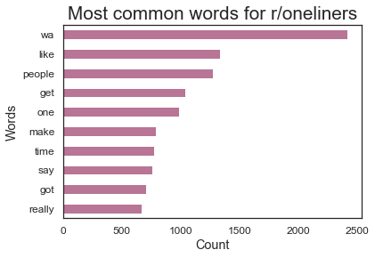

```python
# plot top occuring words for r/outliners
colors = {0:'#B87595', 1:'lightseagreen'}
df_title_ngram1_0_cvec_df.sum().sort_values(ascending=False).head(10).plot(kind='barh',color = colors[0]);
plt.xlabel("Count")
plt.ylabel("Words")
plt.title("Most common words for r/oneliners")
plt.gca().invert_yaxis();
```

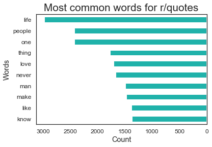

```python
df_title_ngram1_1_cvec_df.sum().sort_values(ascending=False).head(10).plot(kind='barh', color = colors[1]);
plt.xlabel("Count")
plt.ylabel("Words")
plt.title("Most common words for r/quotes")
plt.gca().invert_yaxis();
plt.gca().invert_xaxis();
```

Some interesting insights can be gain:

- There are some words that appear in the top 10 of both subreddits. These are rather typical words such as people, one.
- However, a look at r/quotes reveals that words such as life, love, never, man, know appear exclusively in the top 10 for r/quotes. This shows us that profound topics like life and love are significant in statements from r/quotes.

## Sentence Length

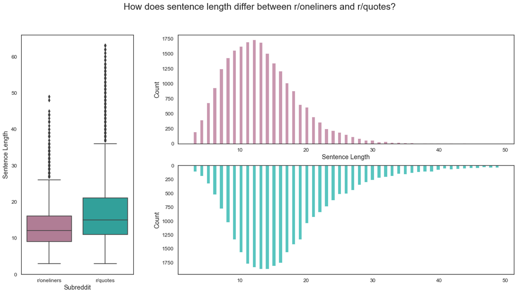

```python
box_and_hist(df = df_non_tags, x = 'subreddit', y = 'title_length', categories = ['r/oneliners', 'r/quotes'],
                            xlabel_box = 'Subreddit', ylabel_box = 'Sentence Length',
                            title = "How does sentence length differ between r/oneliners and r/quotes?")
```

We see that in general, sentence length are longer for sentences from r/quotes compared to r/oneliners.

Let us do the same for average word length.

## Word length

### Average length

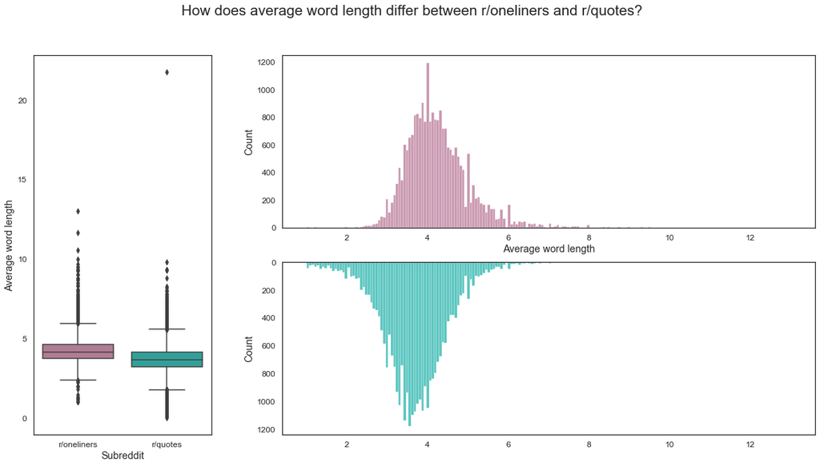

```python
box_and_hist(df = df_non_tags, x = 'subreddit', y = 'average_length', categories = ['r/oneliners', 'r/quotes'],
                            xlabel_box = 'Subreddit', ylabel_box = 'Average word length',
                            title = "How does average word length differ between r/oneliners and r/quotes?")
```

When we do the same for average word length, we see that average word length is actually lower for r/quotes. This is not unexpected since the average word lenth = total letters/number of words.

### Longest length

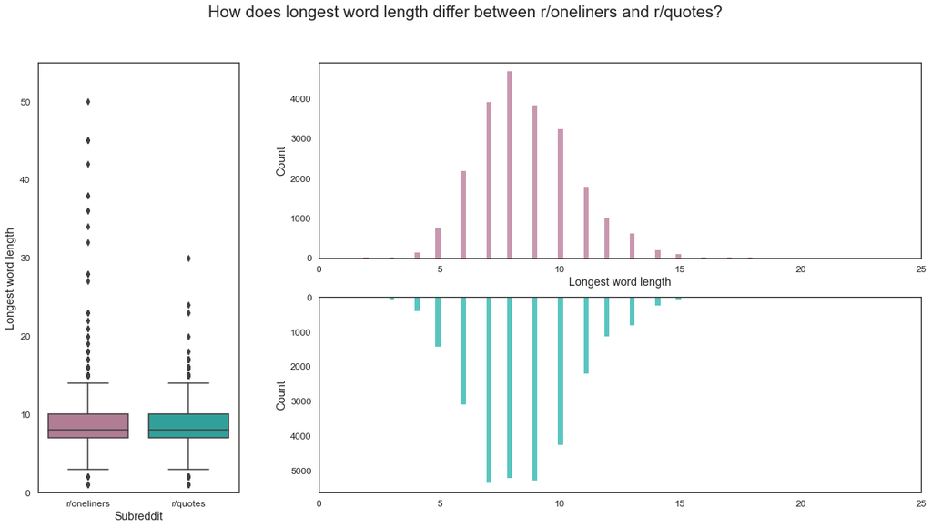

```python
fig = plt.figure(figsize = (20,10))

gs = gridspec.GridSpec(2, 2, figure=fig, width_ratios=[1, 3])

ax0 = fig.add_subplot(gs[:, 0]) # gs[row, col]
ax1 = fig.add_subplot(gs[:1, 1])
ax2 = fig.add_subplot(gs[1:, 1], sharex=ax1)

colors = {0:'#B87595', 1:'lightseagreen'}
sns.boxplot(data = df_non_tags, x = 'subreddit', y = 'longest_length', palette= colors ,ax = ax0)

bin_num = np.histogram_bin_edges(df_non_tags[df_non_tags['subreddit'] == 0]['longest_length'], bins='auto')
sns.histplot(data = df_non_tags[df_non_tags['subreddit'] == 0], x = 'longest_length',
                            bins = bin_num, color = '#B87595', ax = ax1) # r/oneliners
sns.histplot(data = df_non_tags[df_non_tags['subreddit'] == 1], x = 'longest_length',
                            bins = bin_num, color = 'lightseagreen', ax = ax2) # r/quotes

ax2.invert_yaxis()
ax0.set_ylim(0, 55)
ax0.set_xticklabels(['r/oneliners', 'r/quotes'])
ax0.set_xlabel('Subreddit')
ax0.set_ylabel('Longest word length')
ax1.set_xlabel('Longest word length')
ax2.set_xlabel(None)
ax1.set_xlim(0,25)
ax2.set_xlim(0,25)
plt.suptitle("How does longest word length differ between r/oneliners and r/quotes?", fontsize = "xx-large");
```

There are also no significant difference in terms of the longest word length of a sentence.

However, we do see that r/oneliners has more outliners in terms of the longest word length. This could be due to cases such as this one.

```python
df_non_tags[df_non_tags['longest_length'] == 177]['title'].values[0]
```

```
'I should have some oneliner that might be interesting but i dont think it will fit in the title yo whats the limit in this thinglafaaaaaaaaaaaaaaaaaaaaaaaaaaaaaaaaaaaaaaaaaaaaaaaaaaaaaaaaaaaaaaaaaaaaaaaaaaaaaaaaaaaaaaaaaaaaaaaaaaaaaaaaaaaaaaaaaaaaaaaaaaaaaaaaaaaaaaaaaaaaaaaaaaaaaaaaaaaaaaaaaaaaaaaa…
```

## Dale–Chall readeability score

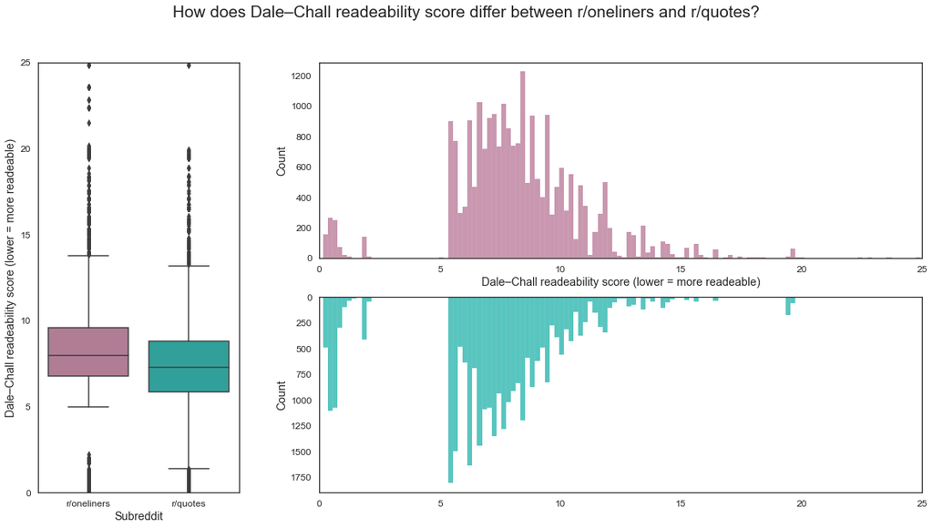

```python
fig = plt.figure(figsize = (20,10))

gs = gridspec.GridSpec(2, 2, figure=fig, width_ratios=[1, 3])

ax0 = fig.add_subplot(gs[:, 0]) # gs[row, col]
ax1 = fig.add_subplot(gs[:1, 1])
ax2 = fig.add_subplot(gs[1:, 1], sharex=ax1)

colors = {0:'#B87595', 1:'lightseagreen'}
sns.boxplot(data = df_non_tags, x = 'subreddit', y = 'Dale–Chall_readeability_score', palette= colors ,ax = ax0)

bin_num = np.histogram_bin_edges(df_non_tags[df_non_tags['subreddit'] == 0]['Dale–Chall_readeability_score'], bins='auto')
sns.histplot(data = df_non_tags[df_non_tags['subreddit'] == 0], x = 'Dale–Chall_readeability_score',
                            bins = bin_num, color = '#B87595', ax = ax1) # r/oneliners
sns.histplot(data = df_non_tags[df_non_tags['subreddit'] == 1], x = 'Dale–Chall_readeability_score',
                            bins = bin_num, color = 'lightseagreen', ax = ax2) # r/quotes

ax2.invert_yaxis()
ax0.set_ylim(0, 25)
ax0.set_xticklabels(['r/oneliners', 'r/quotes'])
ax0.set_xlabel('Subreddit')
ax0.set_ylabel('Dale–Chall readeability score (lower = more readeable)')
ax1.set_xlabel('Dale–Chall readeability score (lower = more readeable)')
ax2.set_xlabel(None)
ax1.set_xlim(0,25)
ax2.set_xlim(0,25)
plt.suptitle("How does Dale–Chall readeability score differ between r/oneliners and r/quotes?", fontsize = "xx-large");
```

To our surprise, we see that sentences from r/oneliners are actually less readeable in general than r/quotes.

We speculate that it could be because the Dale–Chall readeability score is computed as a function of the percentage of words in the list of 3000 easy words. As such, mispelled words, or words such as internet slangs, which would appear more in r/oneliners, would not be within the 3000 easy word list.

## Flesch reading ease

Now what about the Flesch reading ease, which does not rely on a corpus of words. For Flesch reading ease, the lower the score, the lower the sentence readeability.

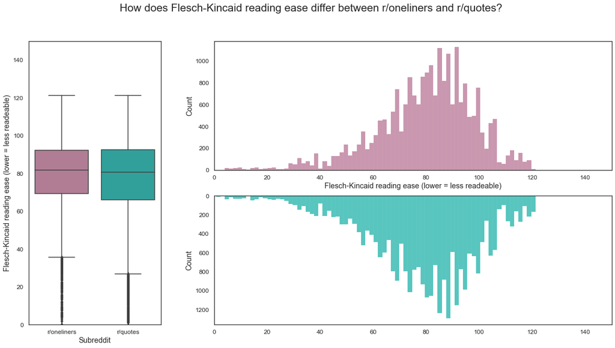

```python
fig = plt.figure(figsize = (20,10))

gs = gridspec.GridSpec(2, 2, figure=fig, width_ratios=[1, 3])

ax0 = fig.add_subplot(gs[:, 0]) # gs[row, col]
ax1 = fig.add_subplot(gs[:1, 1])
ax2 = fig.add_subplot(gs[1:, 1], sharex=ax1)

colors = {0:'#B87595', 1:'lightseagreen'}
sns.boxplot(data = df_non_tags, x = 'subreddit', y = 'Flesch-Kincaid_reading_ease', palette= colors ,ax = ax0)

bin_num = np.histogram_bin_edges(df_non_tags[df_non_tags['subreddit'] == 0]['Flesch-Kincaid_reading_ease'], bins='auto')
sns.histplot(data = df_non_tags[df_non_tags['subreddit'] == 0], x = 'Flesch-Kincaid_reading_ease',
                            bins = bin_num, color = '#B87595', ax = ax1) # r/oneliners
sns.histplot(data = df_non_tags[df_non_tags['subreddit'] == 1], x = 'Flesch-Kincaid_reading_ease',
                            bins = bin_num, color = 'lightseagreen', ax = ax2) # r/quotes

ax2.invert_yaxis()
ax0.set_ylim(0, 150)
ax0.set_xticklabels(['r/oneliners', 'r/quotes'])
ax0.set_xlabel('Subreddit')
ax0.set_ylabel('Flesch-Kincaid reading ease (lower = less readeable)')
ax1.set_xlabel('Flesch-Kincaid reading ease (lower = less readeable)')
ax2.set_xlabel(None)
ax1.set_xlim(0,150)
ax2.set_xlim(0,150)
plt.suptitle("How does Flesch-Kincaid reading ease differ between r/oneliners and r/quotes?", fontsize = "xx-large");
```

Again, it doesn't seem that there are much difference, although we do observe that r/quotes have more sentences with reading ease score on the lower end.

## Sentiment Score

We will plot each of the sentiment distributions.

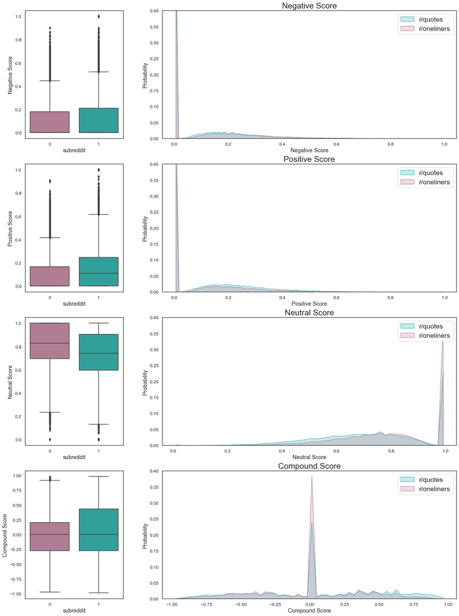

```python
# Plot boxplot and probability distribution of each sentiment score

f, (a0, a1, a2, a3) = plt.subplots(4, 2, gridspec_kw={'width_ratios': [1, 3]}, figsize = (20, 28))
colors = {0:'#B87595', 1:'lightseagreen'}

# Create dictionary of axes and loop through to plot
axes_dict = {
                            'Negative Score': {'col':'sentiment_negative_score', 'axis': a0},
                            'Positive Score': {'col':'sentiment_positive_score', 'axis': a1},
                            'Neutral Score': {'col':'sentiment_neutral_score', 'axis': a2},
                            'Compound Score': {'col':'sentiment_compound_score', 'axis': a3}
}

for label, axis_info in axes_dict.items():
                            sns.boxplot(data = df, x = 'subreddit', y = axis_info['col'], palette=colors, ax=axis_info['axis'][0]);
                            sns.histplot(data = df, x =axis_info['col'], hue = 'subreddit', ax = axis_info['axis'][1], palette=colors,
                            element = 'poly', stat = 'probability', multiple = 'layer', common_norm=False)
                            axis_info['axis'][0].set_ylabel(label)
                            axis_info['axis'][1].set_xlabel(label)
                            axis_info['axis'][1].set_ylim(0,0.4)
                            axis_info['axis'][1].set_title(label)
                            axis_info['axis'][1].legend(["r/quotes", "r/oneliners"]);
```

Generally, in terms of sentiments, we observe that sentences from r/oneliners have a higher proportion of neutral sentences, the sentences from r/quotes have a higher proportion of sentences with positive sentiments.

## Number of commas

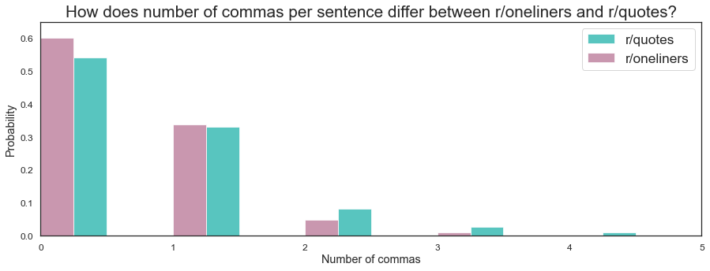

```python
fig, ax = plt.subplots(figsize = (15,5))

colors = {0:'#B87595', 1:'lightseagreen'}
bin_num = np.histogram_bin_edges(df[','], bins='auto')
sns.histplot(data = df , x = ',', bins = bin_num, hue = 'subreddit',
                            stat = "probability", palette=colors, multiple = 'dodge', binwidth=0.5, common_norm=False)
plt.xlabel('Number of commas')
plt.xlim(0,5)
plt.ylim(0,0.65)
plt.legend(["r/quotes", "r/oneliners"])
plt.title("How does number of commas per sentence differ between r/oneliners and r/quotes?", fontsize = "xx-large");
```

Here, we see that there are a higher percentage of sentences from r/oneliners with 0 commas, while for a higher percentage of sentences from r/quotes has 2 or more commas.

## Word tag comparison

```python
df_tags_y = pd.concat([df_tags, df['subreddit'], df['title_length']], axis = 1)
df_tags_y.head()
```

|  | # | $ | '' | ( | ) | , | . | : | CC | CD | DT | EX | FW | IN | JJ | JJR | JJS | MD | NN | NNP | NNPS | NNS | PDT | POS | PRP | PRP$ | RB | RBR | RBS | … |
| --- | --- | --- | --- | --- | --- | --- | --- | --- | --- | --- | --- | --- | --- | --- | --- | --- | --- | --- | --- | --- | --- | --- | --- | --- | --- | --- | --- | --- | --- | --- |
| 0 | 0.0 | 0.0 | 0.0 | 0.0 | 0.0 | 2.0 | 1.0 | 0.0 | 2.0 | 0.0 | 1.0 | 0.0 | 0.0 | 0.0 | 2.0 | 0.0 | 0.0 | 0.0 | 1.0 | 0.0 | 0.0 | 0.0 | 0.0 | 0.0 | 4.0 | 1.0 | 3.0 | 0.0 | 0.0 | … |
| 1 | 0.0 | 0.0 | 0.0 | 0.0 | 0.0 | 0.0 | 0.0 | 0.0 | 0.0 | 0.0 | 1.0 | 0.0 | 0.0 | 0.0 | 2.0 | 0.0 | 0.0 | 0.0 | 2.0 | 1.0 | 0.0 | 1.0 | 0.0 | 0.0 | 1.0 | 0.0 | 1.0 | 0.0 | 0.0 | … |
| 2 | 0.0 | 0.0 | 0.0 | 0.0 | 0.0 | 3.0 | 0.0 | 0.0 | 0.0 | 0.0 | 2.0 | 0.0 | 0.0 | 3.0 | 0.0 | 0.0 | 0.0 | 0.0 | 4.0 | 4.0 | 0.0 | 1.0 | 0.0 | 0.0 | 1.0 | 2.0 | 0.0 | 0.0 | 0.0 | … |
| 3 | 0.0 | 0.0 | 0.0 | 0.0 | 0.0 | 1.0 | 0.0 | 0.0 | 1.0 | 0.0 | 0.0 | 0.0 | 0.0 | 0.0 | 2.0 | 0.0 | 0.0 | 1.0 | 0.0 | 0.0 | 0.0 | 4.0 | 0.0 | 0.0 | 1.0 | 0.0 | 1.0 | 0.0 | 0.0 | … |
| 4 | 0.0 | 0.0 | 0.0 | 0.0 | 0.0 | 1.0 | 0.0 | 0.0 | 0.0 | 0.0 | 4.0 | 0.0 | 0.0 | 3.0 | 1.0 | 0.0 | 0.0 | 0.0 | 6.0 | 0.0 | 0.0 | 1.0 | 0.0 | 0.0 | 0.0 | 0.0 | 2.0 | 0.0 | 0.0 | … |

### Per word

Here we look at the average occurence of word tags per word.

```python
# Per word
# Get the mean occurence of each word tag, then combined into a dataframe
df_tags_0_mean = df_tags_y[df_tags_y['subreddit']==0].sum()/df_tags_y[df_tags_y['subreddit']==0].sum()['title_length']
df_tags_1_mean = df_tags_y[df_tags_y['subreddit']==1].sum()/df_tags_y[df_tags_y['subreddit']==1].sum()['title_length']
df_tags_combined_mean_word = pd.concat([df_tags_0_mean, df_tags_1_mean], axis = 1).T
```

```python
# sort order by frequency of occurance of r/oneliners
ordered_cols = df_tags_0_mean.drop(['subreddit', 'title_length'], axis = 0).sort_values(ascending = False).index
df_tags_combined_mean_word = df_tags_combined_mean_word[ordered_cols]
df_tags_combined_mean_word
```

|  | NN | PRP | IN | DT | JJ | RB | . | VBP | VB | NNS | NNP | VBD | , | VBZ | PRP$ | TO | CC | VBG | VBN | MD | CD | WRB | : | RP | WP | '' | `` | POS | WDT | … |
| --- | --- | --- | --- | --- | --- | --- | --- | --- | --- | --- | --- | --- | --- | --- | --- | --- | --- | --- | --- | --- | --- | --- | --- | --- | --- | --- | --- | --- | --- | --- |
| 0 | 0.167798 | 0.100296 | 0.095774 | 0.090042 | 0.066766 | 0.057675 | 0.056307 | 0.051614 | 0.048539 | 0.047632 | 0.044954 | 0.044017 | 0.036643 | 0.036010 | 0.028064 | 0.025523 | 0.023881 | 0.023471 | 0.016510 | 0.015597 | 0.011212 | 0.009988 | 0.007477 | 0.006817 | 0.005373 | 0.004881 | 0.004296 | 0.003393 | 0.002747 | … |
| 1 | 0.131278 | 0.076907 | 0.092513 | 0.081848 | 0.055347 | 0.053661 | 0.028882 | 0.047556 | 0.055727 | 0.038720 | 0.031275 | 0.011044 | 0.038608 | 0.043156 | 0.016515 | 0.028156 | 0.026310 | 0.016126 | 0.014207 | 0.017726 | 0.005790 | 0.008702 | 0.007707 | 0.003627 | 0.010550 | 0.000868 | 0.000488 | 0.001610 | 0.004473 | … |

```python
# By ratio - get the ratio of occurance of a word tags of r/oneliners vs r/quotes
df_tags_combined_mean_word_ratio = df_tags_combined_mean_word.T

# function to return 'ratio' column, to return whichever gives the larger ratio
# negative ratio if r/quotes have a larger number
def word_tag_ratio(row):
                            row['ratio'] = row[0]/row[1] if row[0]>row[1] else -row[1]/row[0]
                            if row['ratio']>0:
                            row['legend'] = "r/oneliners more"
                            else:
                            row['legend'] = "r/quotes more"
                            return row
df_tags_combined_mean_word_ratio = df_tags_combined_mean_word_ratio.apply(word_tag_ratio, axis = 1).sort_values('ratio',ascending = False).reset_index()
df_tags_combined_mean_word_ratio.tail()
```

|  | index | 0 | 1 | ratio | legend |
| --- | --- | --- | --- | --- | --- |
| 39 | WDT | 0.002747 | 0.004473 | -1.628653 | r/quotes more |
| 40 | RBR | 0.001115 | 0.001962 | -1.759634 | r/quotes more |
| 41 | WP | 0.005373 | 0.010550 | -1.963425 | r/quotes more |
| 42 | RBS | 0.000458 | 0.001173 | -2.559094 | r/quotes more |
| 43 | WP$ | 0.000034 | 0.000126 | -3.682347 | r/quotes more |

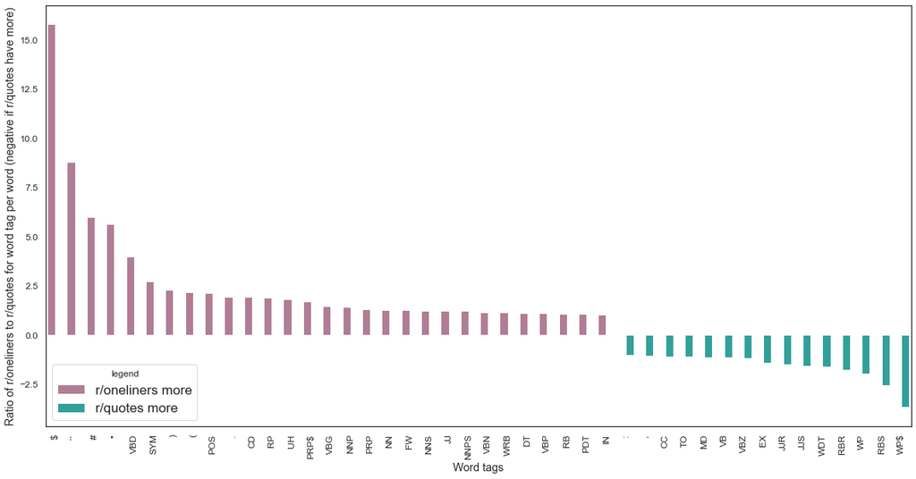

```python
# plot ratio bar chart
plt.figure(figsize = (20, 10))
colors = {'r/oneliners more':'#B87595', 'r/quotes more':'lightseagreen'}
sns.barplot(data = df_tags_combined_mean_word_ratio, x = 'index', y = 'ratio', hue = 'legend', palette=colors)
plt.xticks(rotation = 90);
plt.xlabel('Word tags')
plt.ylabel('Ratio of r/oneliners to r/quotes for word tag per word (negative if r/quotes have more)');
```

### Per sentence

Here we look at the average occurence of word tags per sentence.

```python
# Per sentence
# Get the mean occurence of each word tag, then combined into a dataframe
df_tags_0_mean = df_tags_y[df_tags_y['subreddit']==0].mean()
df_tags_1_mean = df_tags_y[df_tags_y['subreddit']==1].mean()
df_tags_combined_mean_sent = pd.concat([df_tags_0_mean, df_tags_1_mean], axis = 1).T
df_tags_combined_mean_sent = df_tags_combined_mean_sent[ordered_cols]
```

```python
# By ratio - get the ratio of occurance of a word tags of r/oneliners vs r/quotes (minus 1 so that if r/quotes has more, it will be negative)
df_tags_combined_mean_sent_ratio = df_tags_combined_mean_sent.T

# use word_tag_ratio function to get the ratio like previous
df_tags_combined_mean_sent_ratio = df_tags_combined_mean_sent_ratio.apply(word_tag_ratio, axis = 1).sort_values('ratio',ascending = False).reset_index()
df_tags_combined_mean_sent_ratio.tail()
```

|  | index | 0 | 1 | ratio | legend |
| --- | --- | --- | --- | --- | --- |
| 39 | WDT | 0.035722 | 0.076486 | -2.141121 | r/quotes more |
| 40 | RBR | 0.014502 | 0.033549 | -2.313316 | r/quotes more |
| 41 | WP | 0.069887 | 0.180396 | -2.581232 | r/quotes more |
| 42 | RBS | 0.005961 | 0.020055 | -3.364332 | r/quotes more |
| 43 | WP$ | 0.000445 | 0.002154 | -4.841026 | r/quotes more |

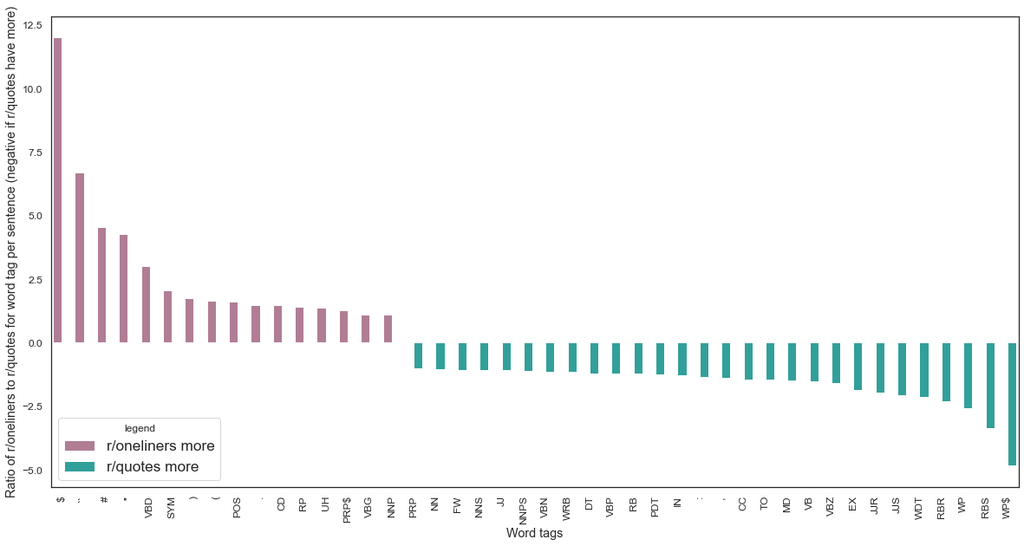

```python
# plot ratio bar chart
plt.figure(figsize = (20, 10))
colors = {'r/oneliners more':'#B87595', 'r/quotes more':'lightseagreen'}
sns.barplot(data = df_tags_combined_mean_sent_ratio, x = 'index', y = 'ratio', hue = 'legend', palette=colors)
plt.xticks(rotation = 90);
plt.xlabel('Word tags')
plt.ylabel('Ratio of r/oneliners to r/quotes for word tag per sentence (negative if r/quotes have more)');
```

Notable tags with **r/oneliners** more:

- symobols (other than ‘’ and ,), expressed by the SYM (symbols), \$, # ,etc
- VBD (past tense verb, i.e. played)
- POS (genitive marker' 's, i.e. parent's)
- CD (numeral)
- RP (partical, i.e. about, across, along)
- UH (interjection, i.e. goodbye, huh, Oops)
- PRP$ (possessive pronoun, i.e. I, her, his)
- VBG (present participle, i.e. playing)
- NNP(proper noun, i.e. Escobar, Liverpool)

Notable tags with **r/quotes** more:

- WP$ (WH-pronoun, i.e. whose)
- RBS (adverb, superlative, i.e. best, biggest)
- WP (WH-pronoun, i.e. who, whom)
- RBR (comparative adverb, i.e. heavier, higher)
- WDT (WH-determiner, i.e. what, whatever)
- JJS (adjective superlative, i.e. calmest, dearest)
- JJR (comparative adjective, i.e. bleaker, breezier)
- EX (existential there, i.e. there)
- VBZ (present tense verb, i.e. plays, snatches)
- VB (base form verb, i.e. play, snatch)
- MD (modal auxiliary, i.e. can, may)
- TO (to)
- CC (conjunction, i.e. and, either, nor)
- , (comma)

From this analysis, we see that those tags with r/oneliners more generally are less formal, such as symbols, numerals, proper nouns, as well as verbs with a time setting, such as past tense, and present participle, as well as interjection like Oops, huh, etc.

For tags with r/quotes more, we see that the most notable ones are grammars just to increase sentence complexity, such as whose, whom, and, nor, as well as comparative grammars like, best, bleaker, etc.

```python
# get word tag explanation by keying in the abbrevation as argument
#nltk.help.upenn_tagset('CC')
```

# Modelling

## Creating Feature sets

We will create a few feature sets in order to iteratively get the best set of features to use for our modelling.

First, let us take a look at the features we have for now.

```python
df.head(2)
```

|  | title | title_length | subreddit | average_length | longest_length | Dale–Chall_readeability_score | Flesch-Kincaid_reading_ease | sentiment_negative_score | sentiment_neutral_score | sentiment_positive_score | sentiment_compound_score | # | $ | '' | ( | ) | , | . | : | CC | CD | DT | EX | FW | IN | ... | NNP | NNPS | NNS | … |
| --- | --- | --- | --- | --- | --- | --- | --- | --- | --- | --- | --- | --- | --- | --- | --- | --- | --- | --- | --- | --- | --- | --- | --- | --- | --- | --- | --- | --- | --- | --- |
| 0 | We all think we're right, and then we change o... | 17.0 | 1 | 4.058824 | 6 | 0.84 | 104.98 | 0.000 | 1.00 | 0.000 | 0.0000 | 0.0 | 0.0 | 0.0 | 0.0 | 0.0 | 2.0 | 1.0 | 0.0 | 2.0 | 0.0 | 1.0 | 0.0 | 0.0 | 0.0 | ... | 0.0 | 0.0 | 0.0 | … |
| 1 | Life feels good cause I just finger the bad bitch | 10.0 | 1 | 4.000000 | 6 | 7.29 | 103.63 | 0.451 | 0.37 | 0.179 | -0.6597 | 0.0 | 0.0 | 0.0 | 0.0 | 0.0 | 0.0 | 0.0 | 0.0 | 0.0 | 0.0 | 1.0 | 0.0 | 0.0 | 0.0 | ... | 1.0 | 0.0 | 1.0 | … |

2 rows × 55 columns

```python
# First we get a dictionary with different dataframes, each dataframe consists of same type of data

# column name groups
feature_sets_col = [['title'], ['title_length'], ['average_length'], ['longest_length'],
                            ['Dale–Chall_readeability_score'], ['Flesch-Kincaid_reading_ease'],
                            list(df.iloc[:, 7:11].columns), list(df.iloc[:, 11:].columns)]

# get combinations of all
feature_sets_col_dict = []
for i in range(1, len(feature_sets_col)+1):
                            combs = list(combinations(feature_sets_col, i))
                            for comb in combs:
                            col_comb = [] # individual combinations
                            for col in comb:
                            col_comb += col # add list of individual items to another list

                            if 'title' in col_comb: # we only want the combinations containing title
                            feature_sets_col_dict.append(col_comb)

# We then split the original dataframe into train and test sets
X = df.drop('subreddit', axis = 1)
y = df['subreddit']
X_train, X_test, y_train, y_test = train_test_split(X, y, test_size=0.05,
                            random_state=1, stratify=y)
# store all dataframes in a dictionary
feature_sets_dict = {i:X_train[col_name] for i, col_name in enumerate(feature_sets_col_dict)}
feature_sets_dict_test = {i:X_test[col_name] for i, col_name in enumerate(feature_sets_col_dict)}
# each value in feature_sets_dict is a df with a unique combination of columns
```

```python
# Training datasets
print("Number of combinations: ", len(feature_sets_dict.keys()))
feature_sets_dict[33].head(1)
```

```
Number of combinations:  128
```

|  | title | title_length | average_length | # | $ | '' | ( | ) | , | . | : | CC | CD | DT | EX | FW | IN | JJ | JJR | JJS | MD | NN | NNP | NNPS | NNS | PDT | POS | PRP | PRP$ | … |
| --- | --- | --- | --- | --- | --- | --- | --- | --- | --- | --- | --- | --- | --- | --- | --- | --- | --- | --- | --- | --- | --- | --- | --- | --- | --- | --- | --- | --- | --- | --- |
| 24435 | The greatest prison people live in is the fear... | 16.0 | 3.75 | 0.0 | 0.0 | 0.0 | 0.0 | 0.0 | 0.0 | 1.0 | 0.0 | 0.0 | 0.0 | 2.0 | 0.0 | 0.0 | 2.0 | 1.0 | 0.0 | 1.0 | 0.0 | 2.0 | 0.0 | 0.0 | 2.0 | 0.0 | 0.0 | 0.0 | 0.0 | … |

```python
#Test data sets
feature_sets_dict_test[33].head(1)
```

|  | title | title_length | average_length | # | $ | '' | ( | ) | , | . | : | CC | CD | DT | EX | FW | IN | JJ | JJR | JJS | MD | NN | NNP | NNPS | NNS | PDT | POS | PRP | PRP$ | … |
| --- | --- | --- | --- | --- | --- | --- | --- | --- | --- | --- | --- | --- | --- | --- | --- | --- | --- | --- | --- | --- | --- | --- | --- | --- | --- | --- | --- | --- | --- | --- |
| 20366 | Better to remain silent and be thought a fool ... | 16.0 | 4.0625 | 0.0 | 0.0 | 0.0 | 0.0 | 0.0 | 0.0 | 1.0 | 0.0 | 2.0 | 0.0 | 2.0 | 0.0 | 0.0 | 1.0 | 1.0 | 0.0 | 0.0 | 0.0 | 2.0 | 0.0 | 0.0 | 0.0 | 0.0 | 0.0 | 0.0 | 0.0 | … |

We have created 128 unique feature sets with different combinations of features.

## Gridsearch through feature combinations with different classifiers

### Baseline Score

```python
y_train.value_counts(normalize = True)
```

```
1    0.569343
0    0.430657
Name: subreddit, dtype: float64
```

The baseline score is the prediction accuracy we would achieve if we were to predict the majority class. Here we see that that score is **0.57**. This is the score we would get if we predict that all sentences belong to r/quotes. Our model has to achieve a higher accuracy than the baseline accuracy.

### Gridsearch through feature sets and vectorizer parameters

#### Run 1: Determine best parameters for Vectorizer

First we will run on a faster classifier, in this case, the logistics regression, in order to determine some basic parameters for our vectorizer.

We will first run on just one feature set.

```python
feature_sets_dict_run1 = {0: feature_sets_dict[33]}
```

```python
vectorizers = {
                            'cvec': {'vectorizer': CountVectorizer(analyzer=lemmatized_words),
                            'params':{'preprocessor__cvec__max_features': [20_000, 30_000],
                            'preprocessor__cvec__min_df': [0, 4],
                            'preprocessor__cvec__ngram_range': [(1,1),(1,2)],
                            'preprocessor__cvec__lowercase': [False, True],
                            'preprocessor__cvec__stop_words':[None, stopwords_custom]}},
                            'tf-idf':{'vectorizer': TfidfVectorizer(analyzer=lemmatized_words),
                            'params':{'preprocessor__tf-idf__max_features': [20_000, 30_000],
                            'preprocessor__tf-idf__min_df': [0, 4],
                            'preprocessor__tf-idf__ngram_range': [(1,1),(1,2)],
                            'preprocessor__tf-idf__lowercase': [False, True],
                            'preprocessor__tf-idf__stop_words':[None, stopwords_custom]}}
}

estimators = {
                            "logreg": {'estimator':LogisticRegression(random_state=1, max_iter=1000),
                            'params': {'logreg__C' : [0.1, 1, 10, 100]}}
}

grid_search_result_1 = find_best_params(feature_sets = feature_sets_dict_run1, response = y_train,
                            vectorizers = vectorizers, estimators = estimators, scaler = MaxAbsScaler(),
                            include_svd = False, scoring = 'accuracy', cv = 4, verbose = 0)
```

```
------------------- Feature Set 0 --------------------
Start cvec
Start logreg without TruncatedSVD
logreg best accuracy score: 0.9116703339291171
Start tf-idf
Start logreg without TruncatedSVD
logreg best accuracy score: 0.9122551837466637
```

```python
grid_search_result_df_1 = pd.DataFrame(grid_search_result_1)
grid_search_result_df_1.head(3)
```

|  | feature_set | vectorizer | estimator | grid search object | best estimator | best score | best params |
| --- | --- | --- | --- | --- | --- | --- | --- |
| 0 | 0 | cvec | logreg | GridSearchCV(cv=4,\n estimator=Pip... | (ColumnTransformer(remainder='passthrough',\n ... | 0.911670 | {'logreg__C': 10, 'preprocessor__cvec__lowerca... |
| 1 | 0 | tf-idf | logreg | GridSearchCV(cv=4,\n estimator=Pip... | (ColumnTransformer(remainder='passthrough',\n ... | 0.912255 | {'logreg__C': 10, 'preprocessor__tf-idf__lower... |

```python
grid_search_result_df_1['best params'].values[0]
```

```
{'logreg__C': 10,
 'preprocessor__cvec__lowercase': False,
 'preprocessor__cvec__max_features': 20000,
 'preprocessor__cvec__min_df': 0,
 'preprocessor__cvec__ngram_range': (1, 1),
 'preprocessor__cvec__stop_words': None}
```

From the above, we see that the better vectorizer is the TF-IDF vectorizer.

#### Run 2: Determine Best Feature Set

Next we will run the gridsearch through different datasets to determine the best dataset.

```python
vectorizers = {
                            'tf-idf':{'vectorizer': TfidfVectorizer(analyzer=lemmatized_words),
                            'params':{'preprocessor__tf-idf__max_features': [30_000],
                            'preprocessor__tf-idf__min_df': [0],
                            'preprocessor__tf-idf__ngram_range': [(1,1)],
                            'preprocessor__tf-idf__lowercase': [False],
                            'preprocessor__tf-idf__stop_words':[None]}}
}

estimators = {
                            "logreg": {'estimator':LogisticRegression(random_state=1, max_iter=1000),
                            'params': {'logreg__C' : [10]}},
}

grid_search_result_2 = find_best_params(feature_sets = feature_sets_dict, response = y_train, vectorizers = vectorizers,
                            estimators = estimators, scaler = MaxAbsScaler(),
                            include_svd = False, scoring = 'accuracy', cv = 4, verbose = 0)
```

```
------------------- Feature Set 0 --------------------
Start tf-idf
Start logreg without TruncatedSVD
logreg best accuracy score: 0.8455441082340363
------------------- Feature Set 1 --------------------
Start tf-idf
Start logreg without TruncatedSVD
logreg best accuracy score: 0.8580675531139416
------------------- Feature Set 2 --------------------
Start tf-idf
Start logreg without TruncatedSVD
logreg best accuracy score: 0.87962568908887
------------------- Feature Set 3 --------------------
Start tf-idf
Start logreg without TruncatedSVD
logreg best accuracy score: 0.8481455977506347
------------------- Feature Set 4 --------------------
Start tf-idf
Start logreg without TruncatedSVD
logreg best accuracy score: 0.8465726040137692
------------------- Feature Set 5 --------------------
Start tf-idf
Start logreg without TruncatedSVD
logreg best accuracy score: 0.845463432169297
------------------- Feature Set 6 --------------------
Start tf-idf
Start logreg without TruncatedSVD
logreg best accuracy score: 0.846411282794037
------------------- Feature Set 7 --------------------
Start tf-idf
Start logreg without TruncatedSVD
logreg best accuracy score: 0.8624235741880635
------------------- Feature Set 8 --------------------
Start tf-idf
Start logreg without TruncatedSVD
logreg best accuracy score: 0.8837396917297466
------------------- Feature Set 9 --------------------
Start tf-idf
Start logreg without TruncatedSVD
logreg best accuracy score: 0.861919361391366
```

[output cut: 457 more lines]

```
Start tf-idf
Start logreg without TruncatedSVD
logreg best accuracy score: 0.913505533417236
------------------- Feature Set 125 --------------------
Start tf-idf
Start logreg without TruncatedSVD
logreg best accuracy score: 0.9087865717285847
------------------- Feature Set 126 --------------------
Start tf-idf
Start logreg without TruncatedSVD
logreg best accuracy score: 0.8998326233982796
------------------- Feature Set 127 --------------------
Start tf-idf
Start logreg without TruncatedSVD
logreg best accuracy score: 0.9135055301635785
```

```python
grid_search_result_df_2 = pd.DataFrame(grid_search_result_2).sort_values(by = "best score", ascending = False)
grid_search_result_df_2.head(20)
```

|  | feature_set | vectorizer | estimator | grid search object | best estimator | best score | best params |
| --- | --- | --- | --- | --- | --- | --- | --- |
| 106 | 106 | tf-idf | logreg | GridSearchCV(cv=4,\n estimator=Pip... | (ColumnTransformer(remainder='passthrough',\n ... | 0.913546 | {'logreg__C': 10, 'preprocessor__tf-idf__lower... |
| 124 | 124 | tf-idf | logreg | GridSearchCV(cv=4,\n estimator=Pip... | (ColumnTransformer(remainder='passthrough',\n ... | 0.913506 | {'logreg__C': 10, 'preprocessor__tf-idf__lower... |
| 127 | 127 | tf-idf | logreg | GridSearchCV(cv=4,\n estimator=Pip... | (ColumnTransformer(remainder='passthrough',\n ... | 0.913506 | {'logreg__C': 10, 'preprocessor__tf-idf__lower... |
| 108 | 108 | tf-idf | logreg | GridSearchCV(cv=4,\n estimator=Pip... | (ColumnTransformer(remainder='passthrough',\n ... | 0.913385 | {'logreg__C': 10, 'preprocessor__tf-idf__lower... |
| 123 | 123 | tf-idf | logreg | GridSearchCV(cv=4,\n estimator=Pip... | (ColumnTransformer(remainder='passthrough',\n ... | 0.913284 | {'logreg__C': 10, 'preprocessor__tf-idf__lower... |
| 121 | 121 | tf-idf | logreg | GridSearchCV(cv=4,\n estimator=Pip... | (ColumnTransformer(remainder='passthrough',\n ... | 0.913243 | {'logreg__C': 10, 'preprocessor__tf-idf__lower... |
| 104 | 104 | tf-idf | logreg | GridSearchCV(cv=4,\n estimator=Pip... | (ColumnTransformer(remainder='passthrough',\n ... | 0.912901 | {'logreg__C': 10, 'preprocessor__tf-idf__lower... |
| 101 | 101 | tf-idf | logreg | GridSearchCV(cv=4,\n estimator=Pip... | (ColumnTransformer(remainder='passthrough',\n ... | 0.912901 | {'logreg__C': 10, 'preprocessor__tf-idf__lower... |
| 107 | 107 | tf-idf | logreg | GridSearchCV(cv=4,\n estimator=Pip... | (ColumnTransformer(remainder='passthrough',\n ... | 0.912880 | {'logreg__C': 10, 'preprocessor__tf-idf__lower... |
| 122 | 122 | tf-idf | logreg | GridSearchCV(cv=4,\n estimator=Pip... | (ColumnTransformer(remainder='passthrough',\n ... | 0.912860 | {'logreg__C': 10, 'preprocessor__tf-idf__lower... |
| 73 | 73 | tf-idf | logreg | GridSearchCV(cv=4,\n estimator=Pip... | (ColumnTransformer(remainder='passthrough',\n ... | 0.912780 | {'logreg__C': 10, 'preprocessor__tf-idf__lower... |
| 70 | 70 | tf-idf | logreg | GridSearchCV(cv=4,\n estimator=Pip... | (ColumnTransformer(remainder='passthrough',\n ... | 0.912780 | {'logreg__C': 10, 'preprocessor__tf-idf__lower... |
| 72 | 72 | tf-idf | logreg | GridSearchCV(cv=4,\n estimator=Pip... | (ColumnTransformer(remainder='passthrough',\n ... | 0.912598 | {'logreg__C': 10, 'preprocessor__tf-idf__lower... |
| 103 | 103 | tf-idf | logreg | GridSearchCV(cv=4,\n estimator=Pip... | (ColumnTransformer(remainder='passthrough',\n ... | 0.912578 | {'logreg__C': 10, 'preprocessor__tf-idf__lower... |
| 67 | 67 | tf-idf | logreg | GridSearchCV(cv=4,\n estimator=Pip... | (ColumnTransformer(remainder='passthrough',\n ... | 0.912437 | {'logreg__C': 10, 'preprocessor__tf-idf__lower... |
| 33 | 33 | tf-idf | logreg | GridSearchCV(cv=4,\n estimator=Pip... | (ColumnTransformer(remainder='passthrough',\n ... | 0.912255 | {'logreg__C': 10, 'preprocessor__tf-idf__lower... |
| 110 | 110 | tf-idf | logreg | GridSearchCV(cv=4,\n estimator=Pip... | (ColumnTransformer(remainder='passthrough',\n ... | 0.909553 | {'logreg__C': 10, 'preprocessor__tf-idf__lower... |
| 76 | 76 | tf-idf | logreg | GridSearchCV(cv=4,\n estimator=Pip... | (ColumnTransformer(remainder='passthrough',\n ... | 0.909412 | {'logreg__C': 10, 'preprocessor__tf-idf__lower... |
| 125 | 125 | tf-idf | logreg | GridSearchCV(cv=4,\n estimator=Pip... | (ColumnTransformer(remainder='passthrough',\n ... | 0.908787 | {'logreg__C': 10, 'preprocessor__tf-idf__lower... |
| 111 | 111 | tf-idf | logreg | GridSearchCV(cv=4,\n estimator=Pip... | (ColumnTransformer(remainder='passthrough',\n ... | 0.908766 | {'logreg__C': 10, 'preprocessor__tf-idf__lower... |

#### Best feature set

```python
# Set up dataframe for heatmap
df_rows_list = []
for i, df in feature_sets_dict.items():
                            df_rows = {}
                            for col in df.columns:
                            df_rows[col] = grid_search_result_df_2.loc[i,:]['best score']
                            df_rows_list.append(df_rows)

feature_sets_score_df = pd.DataFrame(df_rows_list)
feature_sets_score_df = feature_sets_score_df.iloc[:,:11].drop(['sentiment_neutral_score', 'sentiment_positive_score', 'sentiment_compound_score'], axis = 1)
feature_sets_score_df.rename({"sentiment_negative_score":"Sentiment Score", "#":"Word tag"}, axis = 1, inplace = True)
feature_sets_score_df.head(3)
```

|  | title | title_length | average_length | longest_length | Dale–Chall_readeability_score | Flesch-Kincaid_reading_ease | Sentiment Score | Word tag |
| --- | --- | --- | --- | --- | --- | --- | --- | --- |
| 0 | 0.845544 | NaN | NaN | NaN | NaN | NaN | NaN | NaN |
| 1 | 0.858068 | 0.858068 | NaN | NaN | NaN | NaN | NaN | NaN |
| 2 | 0.879626 | NaN | 0.879626 | NaN | NaN | NaN | NaN | NaN |

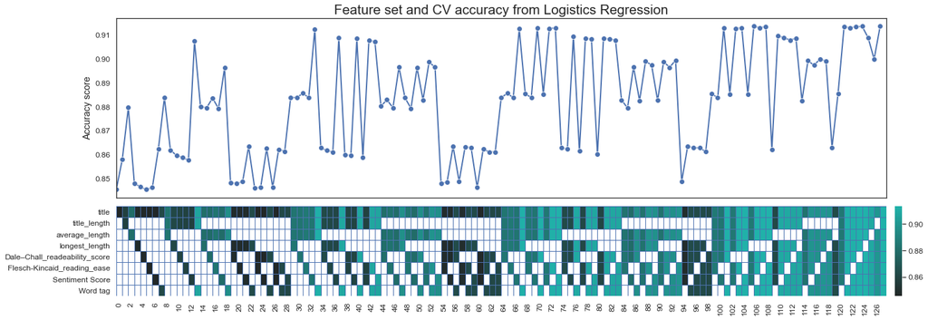

```python
# Plot line plot and heatmap on the same x axis
fig, ax  = plt.subplots(2, 2, sharex='col', figsize = (20, 7),
                            gridspec_kw={'width_ratios':[500,5], 'height_ratios': [2,1]})
ax[0,1].remove()  # remove unused upper right axes

# lineplot
sns.lineplot(x="feature_set", y="best score",
                            data=grid_search_result_df_2,
                            palette='colorblind', marker = 'o', markersize = 8, linewidth = 2, ax = ax[0,0]);
ax[0,0].set_ylabel("Accuracy score")
ax[0,0].set_title("Feature set and CV accuracy from Logistics Regression")

# heatmap
sns.heatmap(feature_sets_score_df.T, cmap=sns.dark_palette("lightseagreen", reverse=False, as_cmap=True),
                            ax=ax[1,0], cbar_ax=ax[1,1],
                            linewidths=1, linecolor='b')
plt.tight_layout()
```

From the result, we see that Feature set 106 has the best accuracy score, however, Feature set 33 is not far off, and it uses 3 lesser additional features than 106. This tells us that the 3 additional features are not that significant in helping us predict the subreddits.Therefore we will select Feature set 33 to go through the next round of modelling.

#### Run 3: Determine Best Estimator

Then we run the different estimators on the best vectorizer parameters and the selected feature set.

```python
# We have selected feature set 33 as the feature set to use
feature_sets_dict_run3 = {0:feature_sets_dict[33]}
```

```python
vectorizers = {
                            'tf-idf':{'vectorizer': TfidfVectorizer(analyzer=lemmatized_words),
                            'params':{'preprocessor__tf-idf__max_features': [30_000],
                            'preprocessor__tf-idf__min_df': [0],
                            'preprocessor__tf-idf__ngram_range': [(1,1)],
                            'preprocessor__tf-idf__lowercase': [False],
                            'preprocessor__tf-idf__stop_words':[None]}}
}

estimators = {
                            "logreg": {'estimator':LogisticRegression(random_state=1, max_iter=1000),
                            'params': {'logreg__C' : [10]}},
                            "gb": {'estimator': GradientBoostingClassifier(random_state=1),
                            'params': {"gb__max_depth": [2,12],
                            'gb__n_estimators': [100,500],
                            'gb__learning_rate': [.02, .15]}},
                            "rf": {'estimator': RandomForestClassifier(random_state=1),
                            'params': {"rf__n_estimators": [100,500],
                            'rf__max_depth': [None, 2, 10]}},
                            "svc": {'estimator': SVC(random_state=1, max_iter=-1),
                            'params': {"svc__C": [0.1, 1, 10, 50],
                            "svc__kernel": ['rbf'],
                            'svc__degree':[2]}}
}

grid_search_result_3 = find_best_params(feature_sets = feature_sets_dict_run3, response = y_train, vectorizers = vectorizers,
                            estimators = estimators, scaler = MaxAbsScaler(),
                            include_svd = False, scoring = 'accuracy', cv = 4, verbose = 0)
```

```
------------------- Feature Set 0 --------------------
Start tf-idf
Start logreg without TruncatedSVD
logreg best accuracy score: 0.9122551837466637
Start gb without TruncatedSVD
gb best accuracy score: 0.8878940153212911
Start rf without TruncatedSVD
rf best accuracy score: 0.863835277614943
Start svc without TruncatedSVD
svc best accuracy score: 0.9176598228453765
```

```python
grid_search_result_df_3 = pd.DataFrame(grid_search_result_3)
grid_search_result_df_3
```

|  | feature_set | vectorizer | estimator | grid search object | best estimator | best score | best params |
| --- | --- | --- | --- | --- | --- | --- | --- |
| 0 | 0 | tf-idf | logreg | GridSearchCV(cv=4,\n estimator=Pip... | (ColumnTransformer(remainder='passthrough',\n ... | 0.912255 | {'logreg__C': 10, 'preprocessor__tf-idf__lower... |
| 1 | 0 | tf-idf | gb | GridSearchCV(cv=4,\n estimator=Pip... | (ColumnTransformer(remainder='passthrough',\n ... | 0.887894 | {'gb__learning_rate': 0.15, 'gb__max_depth': 1... |
| 2 | 0 | tf-idf | rf | GridSearchCV(cv=4,\n estimator=Pip... | (ColumnTransformer(remainder='passthrough',\n ... | 0.863835 | {'preprocessor__tf-idf__lowercase': False, 'pr... |
| 3 | 0 | tf-idf | svc | GridSearchCV(cv=4,\n estimator=Pip... | (ColumnTransformer(remainder='passthrough',\n ... | 0.917660 | {'preprocessor__tf-idf__lowercase': False, 'pr... |

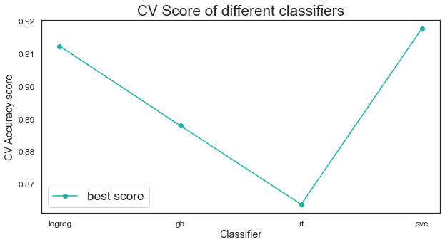

```python
fig, ax = plt.subplots(figsize = (10, 5))
grid_search_result_df_3.plot(x = 'estimator', y = 'best score', marker = 'o', ax = ax, color = 'lightseagreen');
ax.set_xlabel("Classifier")
ax.set_ylabel("CV Accuracy score")
ax.set_title('CV Score of different classifiers');
```

From the result, it looks like our best performing model is the SVC at 0.918 accuracy. Next, we will evaluate our model using then test set.

## Model Evaluation

### Evaluate model on test set

Let us take a look at some of the other evaluation metrics for our best model.

```python
# This is our best classifier, SVC
svc_best_estimator = grid_search_result_df_3.loc[3:]["best estimator"].values[0]
svc_best_estimator
```

```
Pipeline(steps=[('preprocessor',
                 ColumnTransformer(remainder='passthrough',
                                   transformers=[('tf-idf',
                                                  TfidfVectorizer(analyzer=<function lemmatized_words at 0x000002C69519BD30>,
                                                                  lowercase=False,
                                                                  max_features=30000,
                                                                  min_df=0),
                                                  'title')])),
                ('scaler', MaxAbsScaler()),
                ('svc', SVC(C=50, degree=2, random_state=1))])
```

```python
svc_best_estimator.score(feature_sets_dict_test[33], y_test)
```

```
0.9291187739463601
```

```
<sklearn.metrics._plot.confusion_matrix.ConfusionMatrixDisplay at 0x2c68944ff10>
```

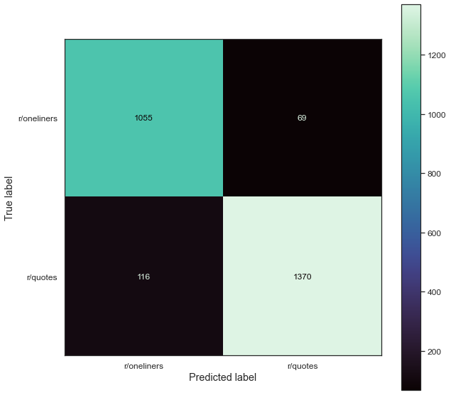

```python
# Let us take a look at the confusion matrix
fig, ax = plt.subplots(figsize = (10, 10))
plot_confusion_matrix(svc_best_estimator, feature_sets_dict_test[33], y_test,
                            display_labels = ['r/oneliners', 'r/quotes'], cmap = 'mako', ax = ax)
```

Let us take a look at some samples of misclassification.

```python
# get prediction on test set
test_pred = svc_best_estimator.predict(feature_sets_dict_test[33])
```

```python
# combined prediction and true value in one dataframe
test_pred_df = pd.concat([feature_sets_dict_test[33][['title']].reset_index(drop = True), y_test.reset_index(drop = True), pd.Series(test_pred, name = 'predicted_subreddit')], axis = 1)

# filter out misclassified samples
misclassified_samples = test_pred_df[test_pred_df['subreddit'] != test_pred_df['predicted_subreddit']]
misclassified_samples.head()
```

|  | title | subreddit | predicted_subreddit |
| --- | --- | --- | --- |
| 19 | Life is like a fan,it keeps moving till someon... | 1 | 0 |
| 30 | Unrequited love: It’s like being addicted to d... | 1 | 0 |
| 34 | Authority will always resort to violence if ig... | 0 | 1 |
| 48 | Stalking is when two people go on a long roman... | 1 | 0 |
| 79 | read and lead rhyme, read and lead rhyme, howe... | 0 | 1 |

We see that some statements from r/oneliners can be rather profound, while vice versa for r/quotes. This is an area for future improvement in terms of obtaining cleaner data.

```python
#misclassified_samples.to_csv("../data/misclassified_sentences.csv", index = False)
```

### Evaluate metric on tweets

To access generalizability, we also take some samples of a tweet from @b0ringtweets, which tweets out boring statements, to give a sense of what are the boring statements, take a look below.

```python
# read in the boring tweets df and apply functions to generate the additional features we need for our model
df_test_1 = pd.read_csv("../data/boring_tweets.csv")

def sentence_length(row):
                            # Using regex to find all words, including those with quotes such as what's
                            split_str = re.findall(r"[\w+|\w+\'\w+]+", row['title'])
                            row['title_length'] = len(split_str)
                            return row


df_test_1 = df_test_1.apply(sentence_length, axis = 1)
df_test_1 = df_test_1.apply(word_length, axis = 1)
df_test_1 = df_test_1.apply(word_tagger, axis = 1)
df_test_1 = df_test_1.apply(empty_col, axis = 1)
df_test_1 = df_test_1.fillna(0)
df_test_1[['title']].head()
```

|  | title |
| --- | --- |
| 0 | Retweet if you're sitting down. |
| 1 | I've been asleep but now I'm awake. |
| 2 | A man is being made the President. |
| 3 | Steve just texted back. |
| 4 | Just texted Steve. |

```python
# order our the tweets dataframe in the order of our dataset
df_test_updated = pd.concat([feature_sets_dict_test[33].iloc[0:0, :], df_test_1]).reset_index(drop = True)
df_test_updated.head(2)
```

|  | title | title_length | average_length | # | $ | '' | ( | ) | , | . | : | CC | CD | DT | EX | FW | IN | JJ | JJR | JJS | MD | NN | NNP | NNPS | NNS | PDT | POS | PRP | PRP$ | … |
| --- | --- | --- | --- | --- | --- | --- | --- | --- | --- | --- | --- | --- | --- | --- | --- | --- | --- | --- | --- | --- | --- | --- | --- | --- | --- | --- | --- | --- | --- | --- |
| 0 | Retweet if you're sitting down. | 5.0 | 5.2 | 0.0 | 0.0 | 0.0 | 0.0 | 0.0 | 0.0 | 1.0 | 0.0 | 0.0 | 0.0 | 0.0 | 0.0 | 0.0 | 1.0 | 0.0 | 0.0 | 0.0 | 0.0 | 1.0 | 0.0 | 0.0 | 0.0 | 0.0 | 0.0 | 1.0 | 0.0 | … |
| 1 | I've been asleep but now I'm awake. | 7.0 | 4.0 | 0.0 | 0.0 | 0.0 | 0.0 | 0.0 | 0.0 | 1.0 | 0.0 | 1.0 | 0.0 | 0.0 | 0.0 | 0.0 | 0.0 | 2.0 | 0.0 | 0.0 | 0.0 | 0.0 | 0.0 | 0.0 | 0.0 | 0.0 | 0.0 | 2.0 | 0.0 | … |

```python
# Perform prediction
prediction = svc_best_estimator.predict(df_test_updated)
tweet_pred_accuracy = 1- sum(prediction)/len(prediction)
tweet_pred_accuracy
```

```
0.9770992366412213
```

Nice! For the very obvious boring tweets, our classifier achieves a much higher score of almost 0.98.

# Conclusion

Let us return to the 3 questions.

**Is there a pattern to profound sentence?**

- Yes, by looking at features like common words, sentence length, word length and word tags, we do see some differences between profound quotes and not so profound sentences. Generally profound quotes tend to have more profound topics such as life and love. They tend to be longer and contain word tags that tend to increase sentence complexity.*

**Can we develop a subreddit classifier to classify statements from r/oneliners vs r/quotes?**

- Yes, to texts which are obviously not so profound, as seen from our prediction of boring tweets, misclassifying only 3 of 131 tweets (0.98 accuracy). However, it can can be quite easily fooled by a human from our tests.*

## Limitations and Future Development

1. Cleaner data: Some sentences from r/oneliners can be profound, while the inverse if true for r/quotes. Future datasets can be more thoroughly labelled to ensure that the data within a class is more homogenous. However, this could require human supervision.
2. Word corpus: a corpus of profound terms or shallow words/internet slangs as reference for our classifier, for example, we could have a feature which is a percentage of words in the sentence which belongs to the corpus.
3. Contextual analysis – Profoundness also depends a lot on context, our model mainly predicts base on word frequency, which does not take into account of context. In the future, contextual analysis methods can be explored.

# Export model as pickle

```python
model = svc_best_estimator
```

```python
# Export model as pickle
path_pickle = r'G:\My Drive\MOOC\20 Data Science Immersive (General Assembly)\03_GIT\dsif-workarea\projects\project_3\code/finalized_model.pkl'
cloudpickle.dump(model, open(path_pickle, 'wb'))
```